# taxi_demand_prediction

```python
import numpy as np
import pandas as pd
import matplotlib.pyplot as plt
from sklearn.cluster import KMeans
from sklearn.metrics import pairwise_distances, mean_squared_error
from sklearn.linear_model import LinearRegression
import seaborn as sns
import warnings
from itertools import product
from xgboost import XGBRegressor, plot_importance
warnings.filterwarnings('ignore')
```

Since this is a demand prediction problem, I have only used the timestamps and the pick up latitude and longitude. I have also analysed customer data below. The drop latitude and longitude are not useful in this regard. If this was a fare prediction problem, it would have been a no-brainer.

```python
%%time
# parse_dates is computationally more efficient than loading the ts as an object (String) and converting it into timestamp
df_taxi = pd.read_csv('ct_rr.csv', usecols=['ts','pick_lat','pick_lng'], parse_dates=['ts'])
df_taxi.drop_duplicates(inplace=True)
```

```
CPU times: user 14.6 s, sys: 2.16 s, total: 16.8 s
Wall time: 16.8 s
```

```python
df_taxi.head()
```

|  | ts | pick_lat | pick_lng |
| --- | --- | --- | --- |
| 0 | 2018-04-07 07:07:17 | 12.313621 | 76.658195 |
| 1 | 2018-04-07 07:32:27 | 12.943947 | 77.560745 |
| 2 | 2018-04-07 07:36:44 | 12.899603 | 77.587300 |
| 3 | 2018-04-07 07:38:00 | 12.918229 | 77.607544 |
| 4 | 2018-04-07 07:39:29 | 12.899490 | 77.587270 |

The features that we can engineer rightaway from the given timestamp are:

```
- minute
- hour
- time in minutes elapsed since midnight which is essentially a combination of the above two feature
- day of the month
- day of the week
- month
- year
```

```python
df_taxi['minute'] = df_taxi['ts'].dt.minute
df_taxi['hour'] = df_taxi['ts'].dt.hour
df_taxi['time_mins'] = df_taxi['hour']*60 + df_taxi['minute']
df_taxi['day'] = df_taxi['ts'].dt.day
df_taxi['dayofweek'] = df_taxi['ts'].dt.dayofweek
df_taxi['month'] = df_taxi['ts'].dt.month
df_taxi['year'] = df_taxi['ts'].dt.year
```

Now let's look at the geographical expanse of Rapido

```python
print('Max Latitude is', df_taxi['pick_lat'].max())
print('Min Latitude is', df_taxi['pick_lat'].min())
print('Max Longitude is', df_taxi['pick_lng'].max())
print('Min Longitude is', df_taxi['pick_lng'].min())
```

```
Max Latitude is 67.69665
Min Latitude is -48.77217
Max Longitude is 92.81411999999999
Min Longitude is -93.95859
```

```python
# https://www.quora.com/What-is-latitude-and-longitude-extent-of-India
df_taxi = df_taxi[(df_taxi['pick_lat']>8)
                  & (df_taxi['pick_lat']<38)
                  & (df_taxi['pick_lng']>68)
                  & (df_taxi['pick_lng']<98)]
```

```python
# Just to check
print('Max Latitude is', df_taxi['pick_lat'].max())
print('Min Latitude is', df_taxi['pick_lat'].min())
print('Max Longitude is', df_taxi['pick_lng'].max())
print('Min Longitude is', df_taxi['pick_lng'].min())
```

```
Max Latitude is 31.332056
Min Latitude is 8.470165
Max Longitude is 92.81411999999999
Min Longitude is 72.48517
```

```python
# The tail of the dataframe
df_taxi.tail()
```

|  | ts | pick_lat | pick_lng | minute | hour | time_mins | day | dayofweek | month | year |
| --- | --- | --- | --- | --- | --- | --- | --- | --- | --- | --- |
| 8381551 | 2019-04-07 23:55:24 | 12.907856 | 77.55787 | 55 | 23 | 1435 | 7 | 6 | 4 | 2019 |
| 8381552 | 2019-04-07 23:58:15 | 12.981010 | 77.69445 | 58 | 23 | 1438 | 7 | 6 | 4 | 2019 |
| 8381553 | 2019-04-07 22:11:20 | 12.924252 | 77.65052 | 11 | 22 | 1331 | 7 | 6 | 4 | 2019 |
| 8381554 | 2019-04-07 22:12:30 | 12.924252 | 77.65052 | 12 | 22 | 1332 | 7 | 6 | 4 | 2019 |
| 8381555 | 2019-04-07 15:00:55 | 12.901222 | 77.59489 | 0 | 15 | 900 | 7 | 6 | 4 | 2019 |

#### Do ride requests have any sort of relation with minutes?

One would not expect this to be the case and it certainly shows.

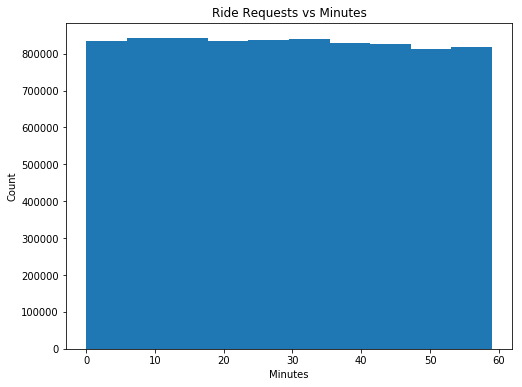

```python
plt.figure(figsize=(8,6))
plt.title('Ride Requests vs Minutes')
plt.hist(df_taxi['minute'], bins=10)
plt.xlabel('Minutes')
plt.ylabel('Count')
```

#### Do ride requests have any sort of relation with the hour of the day?

As someone who works in Bangalore, I would be surprised if there wasn't any relation. The histogram below shows that ride requests peak around the time people go and come back from the office. This timeframe also applies to college students

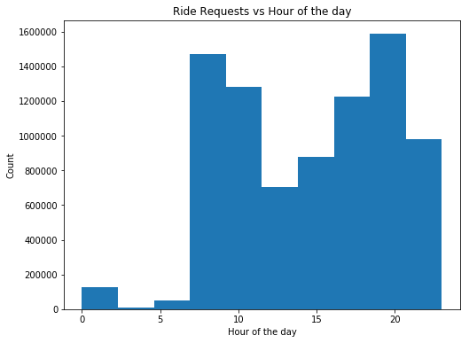

```python
plt.figure(figsize=(8,6))
plt.title('Ride Requests vs Hour of the day')
plt.hist(df_taxi['hour'], bins=10)
plt.xlabel('Hour of the day')
plt.ylabel('Count')
```

The plot below is a smoother representation of the above two features

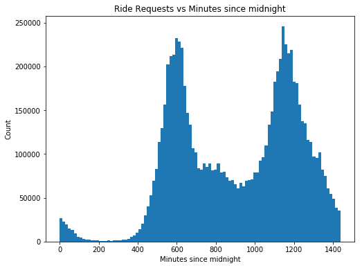

```python
plt.figure(figsize=(8,6))
plt.title('Ride Requests vs Minutes since midnight')
plt.hist(df_taxi['time_mins'], bins=100)
plt.xlabel('Minutes since midnight')
plt.ylabel('Count')
```

#### Do people use Rapido more during the week than the weekend?

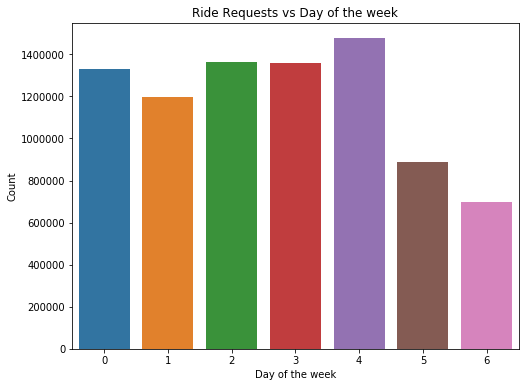

```python
plt.figure(figsize=(8,6))
plt.title('Ride Requests vs Day of the week')
sns.countplot(df_taxi['dayofweek'])
plt.xlabel('Day of the week')
plt.ylabel('Count')
```

#### How does the distribution of the count of ride requests look with respect to the day of the month?

There seems to be no relation here. Although there is a minor downward slope towards the end of the month, it is not concerning enough to be considered as a feature.

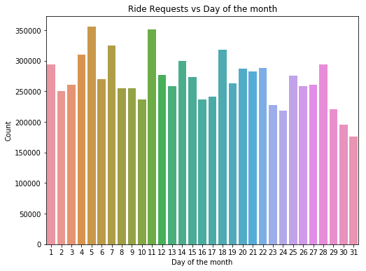

```python
plt.figure(figsize=(8,6))
plt.title('Ride Requests vs Day of the month')
sns.countplot(df_taxi['day'])
plt.xlabel('Day of the month')
plt.ylabel('Count')
```

#### Have the number of ride requests increased with respect to time?

This certainly seems to be the case. There has been a sharp increase in the number of ride requests this year and this is obviously due to the additional number of locations that Rapido now has a presence in

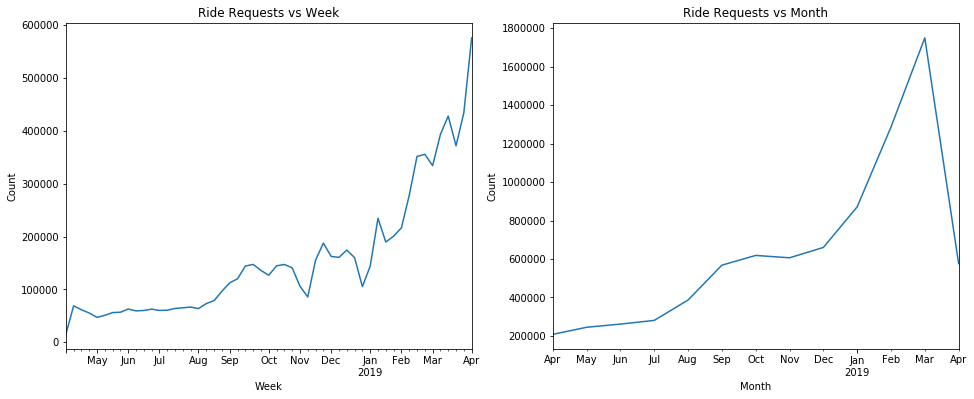

```python
plt.figure(figsize=(16,6))
plt.subplot(121)
plt.title('Ride Requests vs Week')
df_taxi.set_index('ts').resample('W')['pick_lat'].count().plot()
plt.xlabel('Week')
plt.ylabel('Count')

plt.subplot(122)
plt.title('Ride Requests vs Month')
df_taxi.set_index('ts').resample('M')['pick_lat'].count().plot()
plt.xlabel('Month')
plt.ylabel('Count')
```

The dip in the number of ride requests on a weekly basis coincides with Diwali and Christmas. As has been established before, people use Rapido less on holidays. The dip in the requests from March to April 2019 is because we do not have complete data for April 2019 (just the first 7 days)

#### How many "regions" does Rapido ply in?

In order for us to find this, we need to look at a histogram of the latitudes and longitudes.

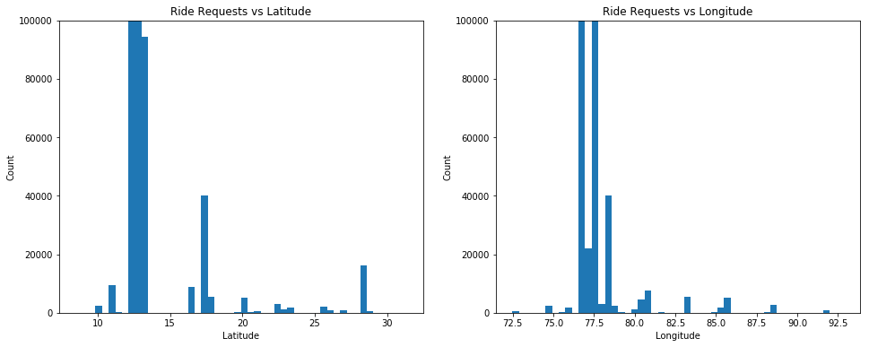

```python
plt.figure(figsize=(16,6))
plt.subplot(121)
plt.title('Ride Requests vs Latitude')
plt.hist(df_taxi['pick_lat'], bins=50)
plt.ylim(0,100000) # Limiting y to see the distribution more clearly
plt.xlabel('Latitude')
plt.ylabel('Count')

plt.subplot(122)
plt.title('Ride Requests vs Longitude')
plt.hist(df_taxi['pick_lng'], bins=50)
plt.ylim(0,100000) # Limiting y to see the distribution more clearly
plt.xlabel('Longitude')
plt.ylabel('Count')
```

The latitudes and longitudes that form the two massive spikes in the histograms are coordinates of various pick up points in Bangalore

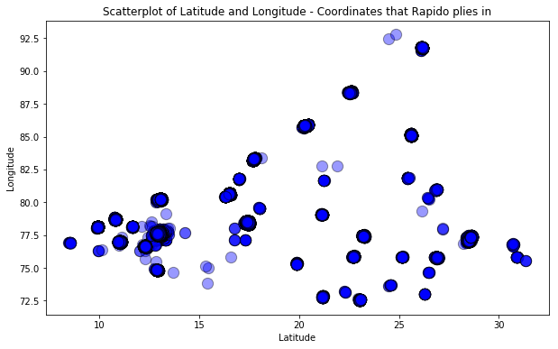

```python
# To now combine the two and plot the coordinates on a scatterplot. This takes some time
fig, ax = plt.subplots()
fig.set_size_inches(10, 6)
plt.title('Scatterplot of Latitude and Longitude - Coordinates that Rapido plies in')
rs_scatter = ax.scatter(df_taxi['pick_lat'], df_taxi['pick_lng'],
                        c='b', edgecolor='k', alpha=0.4, s=150)
plt.xlabel('Latitude')
plt.ylabel('Longitude')
```

According to this article dated March 2019 which is towards the end of timeseries we are working with, Rapido was operational in about 25 cities. https://www.thehindubusinessline.com/economy/logistics/bike-taxi-service-rapido-to-double-its-presence-to-50-cities-in-6-months/article26546085.ece. The reason why this is helpful is because it helps us create clusters from the latitude and longitude data. Ride requests definitely seem to be higher in Bangalore than in other cities and towns.

Now, the right way to cluster geographical coordinates would be to use DBSCAN with haversine distance - DBSCAN is a density based spatial clustering algorithm that clusters points that are closely packed together, haversine distance is just the spherical distance between 2 points. This is something that this paper (https://arxiv.org/pdf/1803.08101.pdf) talks about. This approach helps form clusters that have low intra-geodetic distance, which is what we want. However, the algorithm is computationally very expensive and an alternative would be to use K-Means algorithm. The problem with K-Means is that it tends to form clusters that roughly have an equal number of observations. In our dataset where there are a lot of ride requests from Bangalore, this approach would result in forming more clusters in Bangalore that are not very meaningful. Thus the number of clusters cannot be high. The number of clusters also cannot be low because we would like to cover as many cities as possible. In this case there is also a chance that Mysore and Bangalore get clustered together.

A neat way to check if the clusters are meaningful would be to compute the haversine distance between cluster centres and within clusters and see if it makes sense

```python
# After some elementary hyperparameter tuning, I have settled down on a k of 20
kmeans = KMeans(n_clusters=20, init='k-means++', random_state=0, n_jobs=-1)
kmeans.fit(df_taxi[['pick_lat','pick_lng']])
df_taxi['minor_cluster'] = kmeans.labels_
```

The cluster centres seem to be distributed in a similar fashion to the scatterplot of pick up coordinates. In that sense, the clusters look sensible

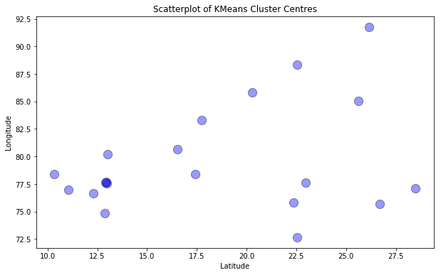

```python
# To now plot the cluster centres
fig, ax = plt.subplots()
fig.set_size_inches(10, 6)
plt.title('Scatterplot of KMeans Cluster Centres')
rs_scatter = ax.scatter(kmeans.cluster_centers_[:,0], kmeans.cluster_centers_[:,1],
                        c='b', edgecolor='k', alpha=.4, s=150)
plt.xlabel('Latitude')
plt.ylabel('Longitude')
```

```python
# A useful function picked up from https://www.kaggle.com/gunbl4d3/xgboost-ing-taxi-fares
def sphere_dist(coord1, coord2):
    """
    Return distance along great radius between two coordinates.
    """
    lat1, lon1 = coord1[0], coord1[1]
    lat2, lon2 = coord2[0], coord2[1]
    #Define earth radius (km)
    R_earth = 6371
    #Convert degrees to radians
    lat1, lon1, lat2, lon2 = map(np.radians, [lat1, lon1, lat2, lon2])
    #Compute distances along lat, lon dimensions
    dlat = lat1 - lat2
    dlon = lon1 - lon2

    #Compute haversine distance
    a = np.sin(dlat/2.0)**2 + np.cos(lat1) * np.cos(lat2) * np.sin(dlon/2.0)**2

    return 2 * R_earth * np.arcsin(np.sqrt(a))
```

```python
# Couldn't use Google Maps API due to a firewall issue. Had to manually enter these coordinates and reverse geocode
# them at https://www.latlong.net/Show-Latitude-Longitude.html
df_clusters = pd.DataFrame()
df_clusters['label'] = np.unique(kmeans.labels_)
df_clusters['centre_latitude'] = kmeans.cluster_centers_[:,0]
df_clusters['centre_longitude'] = kmeans.cluster_centers_[:,1]
df_clusters['name'] = ['Bengaluru East', 'Gurugram', 'Hyderabad', 'Bhubaneshwar', 'Mysore', 'Bhopal', 'Guwahati',
                       'Vijaywada', 'Vishakapatnam','Patna', 'Bengaluru North', 'Coimbatore', 'Chennai', 'Kolkata',
                       'Vadodara', 'Trichy', 'Bengaluru South', 'Mangaluru', 'Jaipur', 'Indore']
df_clusters
```

|  | label | centre_latitude | centre_longitude | name |
| --- | --- | --- | --- | --- |
| 0 | 0 | 12.962932 | 77.677064 | Bengaluru East |
| 1 | 1 | 28.480542 | 77.103686 | Gurugram |
| 2 | 2 | 17.432608 | 78.427918 | Hyderabad |
| 3 | 3 | 20.300397 | 85.823617 | Bhubaneshwar |
| 4 | 4 | 12.314919 | 76.636874 | Mysore |
| 5 | 5 | 22.962203 | 77.645694 | Bhopal |
| 6 | 6 | 26.155996 | 91.774178 | Guwahati |
| 7 | 7 | 16.511165 | 80.645687 | Vijaywada |
| 8 | 8 | 17.740665 | 83.299797 | Vishakapatnam |
| 9 | 9 | 25.602362 | 85.061833 | Patna |
| 10 | 10 | 12.979909 | 77.581922 | Bengaluru North |
| 11 | 11 | 11.031293 | 76.999853 | Coimbatore |
| 12 | 12 | 13.030959 | 80.225960 | Chennai |
| 13 | 13 | 22.551988 | 88.370483 | Kolkata |
| 14 | 14 | 22.525144 | 72.679471 | Vadodara |
| 15 | 15 | 10.341488 | 78.384152 | Trichy |
| 16 | 16 | 12.915162 | 77.615313 | Bengaluru South |
| 17 | 17 | 12.880054 | 74.846421 | Mangaluru |
| 18 | 18 | 26.694984 | 75.720119 | Jaipur |
| 19 | 19 | 22.359679 | 75.809239 | Indore |

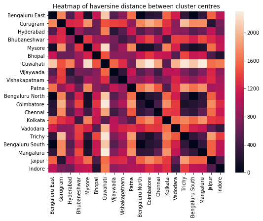

```python
# In order to visualize the inter cluster pairwise distance
plt.figure(figsize=(8,6))
plt.title('Heatmap of haversine distance between cluster centres')
sns.heatmap(pairwise_distances(kmeans.cluster_centers_, metric=sphere_dist), xticklabels=df_clusters['name'], yticklabels=df_clusters['name'])
```

This makes sense as we can see that the cluster centres are meaningfully apart from each other.

From the above plots, we can see that the factors that matter the most with respect to count of ride requests are geography and hour of the day. Thus our aggregation has to be done at an hourly level. There could however be gaps in the timeseries. The problem is the data given to us only contains timestamps when ride requests were placed. It obviously does not contain, timestamps when there was no demand. If we are predicting demand for the future, we would very much like to know demand for all clusters at all hours on all days. Otherwise our model will be very biased and will always predict that there is demand.

```python
# For aggregation
df_model_data = df_taxi.groupby(['year',
                                 'month',
                                 'day',
                                 'dayofweek',
                                 'minor_cluster',
                                 'hour']).size().to_frame('count').reset_index()

# Formatting datetime is expensive. We can instead create a smaller dataframe of dates in a year and merge it
# to the original
date_vars = ['Day','Month','Year']
df_model_data['date'] = pd.to_datetime(df_model_data.rename(columns={'day':'Day','month':'Month','year':'Year'})[date_vars])
df_date = df_model_data[['date']]
df_date = df_date.drop_duplicates()
df_date['day_num'] = [i for i in range(1,df_date.shape[0]+1)]
df_model_data = pd.merge(df_model_data, df_date, how='left', on='date')

# Some useful features
df_model_data['is_weekend'] = df_model_data['dayofweek'].apply(lambda x: 1 if x in [5,6] else 0)
df_model_data['week_num'] = (df_model_data['day_num']/7).astype(int)+1
df_model_data.drop(['day','year','month','date'], axis=1, inplace=True)
```

```python
grid = []
grid_cols = ['minor_cluster', 'hour', 'day_num']
for day_num in df_model_data['day_num'].unique():
    cur_clusters = df_model_data.loc[df_model_data['day_num'] == day_num, 'minor_cluster'].unique()
    cur_hours = np.arange(0,24)
    grid.append(np.array(list(product(*[cur_clusters, cur_hours, [day_num]])),dtype='int32'))
df_grid = pd.DataFrame(np.vstack(grid), columns = grid_cols, dtype=np.int32)
del grid
df_grid = pd.merge(df_grid, df_model_data[grid_cols + ['count']], on=grid_cols, how='left')
# To add in other df_model_data attributes such as is_weekend etc.
df_grid = pd.merge(df_grid, df_model_data[['day_num','dayofweek','is_weekend','week_num']].drop_duplicates(),
                   on=['day_num'], how='left')
# Lags produce null values when there is no demand
df_grid['count'] = df_grid['count'].fillna(0)
# Another useful feature
df_grid['is_midnight'] = df_grid['hour'].apply(lambda x: 1 if x in range(0,8) else 0)
```

```python
# This is what we will use for training our models
df_grid.head()
```

|  | minor_cluster | hour | day_num | count | dayofweek | is_weekend | week_num | is_midnight |
| --- | --- | --- | --- | --- | --- | --- | --- | --- |
| 0 | 0 | 0 | 1 | 0.0 | 5 | 1 | 1 | 1 |
| 1 | 0 | 1 | 1 | 5.0 | 5 | 1 | 1 | 1 |
| 2 | 0 | 2 | 1 | 0.0 | 5 | 1 | 1 | 1 |
| 3 | 0 | 3 | 1 | 0.0 | 5 | 1 | 1 | 1 |
| 4 | 0 | 4 | 1 | 0.0 | 5 | 1 | 1 | 1 |

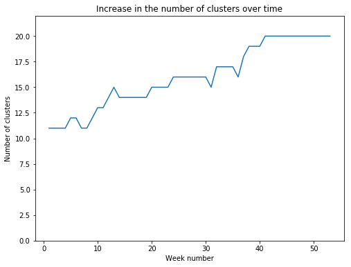

```python
# Increase in the number of clusters over time
plt.figure(figsize=(8,6))
plt.title('Increase in the number of clusters over time')
plt.plot(df_model_data.groupby('week_num').agg(num_clusters=('minor_cluster', 'nunique')))
plt.ylim(0,22)
plt.xlabel('Week number')
plt.ylabel('Number of clusters')
```

Are the dips because of operational hiccups with respect to transport authorities?

All clusters are not the same. The histogram of latitude and longitude shows us that Bangalore is overrepresented. This also leads to the formation of 3 clusters within Bangalore. Thus, a model that predicts ride requests for Bangalore cannot be used for locations such as Patna as the demand in that case will be ridiculously overestimated. This is something that we see in the numerical summary below

```python
df_grid.groupby('minor_cluster')['count'].describe().sort_values('mean', ascending=False)
```

| minor_cluster | count | mean | std | min | 25% | 50% | 75% | max |
| --- | --- | --- | --- | --- | --- | --- | --- | --- |
| 16 | 8784.0 | 448.463115 | 760.683036 | 0.0 | 53.75 | 225.0 | 501.0 | 9851.0 |
| 10 | 8784.0 | 242.411088 | 349.367402 | 0.0 | 27.00 | 141.0 | 295.0 | 4359.0 |
| 0 | 8784.0 | 229.415187 | 404.903946 | 0.0 | 15.00 | 98.0 | 251.0 | 5579.0 |
| 4 | 8784.0 | 14.317964 | 17.701431 | 0.0 | 2.00 | 11.0 | 21.0 | 352.0 |
| 2 | 8784.0 | 4.583106 | 8.003837 | 0.0 | 0.00 | 2.0 | 6.0 | 132.0 |
| 12 | 2088.0 | 2.053161 | 6.080166 | 0.0 | 0.00 | 0.0 | 2.0 | 103.0 |
| 1 | 8736.0 | 1.945284 | 4.055847 | 0.0 | 0.00 | 0.0 | 2.0 | 82.0 |
| 13 | 2448.0 | 1.191993 | 3.688071 | 0.0 | 0.00 | 0.0 | 1.0 | 57.0 |
| 7 | 8592.0 | 1.048999 | 2.621695 | 0.0 | 0.00 | 0.0 | 1.0 | 103.0 |
| 17 | 2640.0 | 0.913636 | 1.985960 | 0.0 | 0.00 | 0.0 | 1.0 | 43.0 |
| 11 | 8136.0 | 0.893068 | 2.164046 | 0.0 | 0.00 | 0.0 | 1.0 | 61.0 |
| 3 | 7056.0 | 0.756094 | 1.939673 | 0.0 | 0.00 | 0.0 | 1.0 | 58.0 |
| 8 | 8352.0 | 0.654574 | 1.735761 | 0.0 | 0.00 | 0.0 | 1.0 | 69.0 |
| 15 | 8280.0 | 0.566304 | 1.464629 | 0.0 | 0.00 | 0.0 | 1.0 | 40.0 |
| 6 | 2448.0 | 0.357026 | 1.156697 | 0.0 | 0.00 | 0.0 | 0.0 | 37.0 |
| 9 | 6600.0 | 0.313788 | 1.291042 | 0.0 | 0.00 | 0.0 | 0.0 | 29.0 |
| 5 | 6504.0 | 0.310271 | 1.533865 | 0.0 | 0.00 | 0.0 | 0.0 | 79.0 |
| 18 | 4008.0 | 0.200848 | 0.771549 | 0.0 | 0.00 | 0.0 | 0.0 | 17.0 |
| 19 | 6264.0 | 0.170977 | 0.785454 | 0.0 | 0.00 | 0.0 | 0.0 | 39.0 |
| 14 | 2952.0 | 0.159553 | 0.763859 | 0.0 | 0.00 | 0.0 | 0.0 | 13.0 |

Cluster ids 16, 10 and 0 (all Bengaluru) need to be in a group of their own. Cluster ids 4 and 2 also need to be in a seperate cluster since their distribution is a bit different from the other towns.

```python
def map_clusters(cluster_id):
    if cluster_id in [0,10,16]:
        return(1)
    elif cluster_id in [2,4]:
        return(2)
    else:
        return(3)

df_grid['major_cluster'] = df_grid['minor_cluster'].map(map_clusters)
```

The numerical summary and plots below show the range of ride requests across the 3 clusters

```python
df_grid.groupby('major_cluster')['count'].describe()
```

| major_cluster | count | mean | std | min | 25% | 50% | 75% | max |
| --- | --- | --- | --- | --- | --- | --- | --- | --- |
| 1 | 26352.0 | 306.763130 | 546.132391 | 0.0 | 28.0 | 148.0 | 343.0 | 9851.0 |
| 2 | 17568.0 | 9.450535 | 14.573383 | 0.0 | 0.0 | 4.0 | 14.0 | 352.0 |
| 3 | 85104.0 | 0.771891 | 2.408673 | 0.0 | 0.0 | 0.0 | 1.0 | 103.0 |

```
(0, 1000)
```

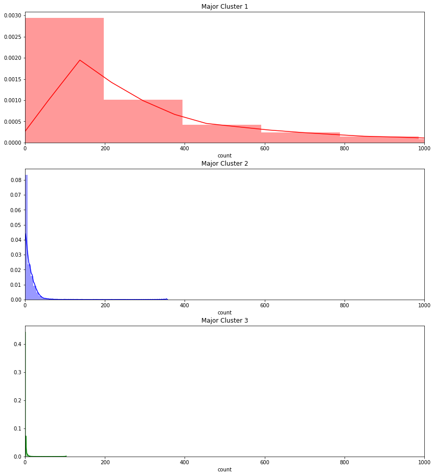

```python
# Distribution of ride requests - simply put, its a count of count
plt.figure(figsize=(14,16))
plt.subplot(311)
plt.title('Major Cluster 1')
sns.distplot(df_grid[df_grid['major_cluster']==1]['count'], color='red')
plt.xlim(0,1000)
plt.subplot(312)
plt.title('Major Cluster 2')
sns.distplot(df_grid[df_grid['major_cluster']==2]['count'], color='blue')
plt.xlim(0,1000)
plt.subplot(313)
plt.title('Major Cluster 3')
sns.distplot(df_grid[df_grid['major_cluster']==3]['count'], color='green')
plt.xlim(0,1000)
```

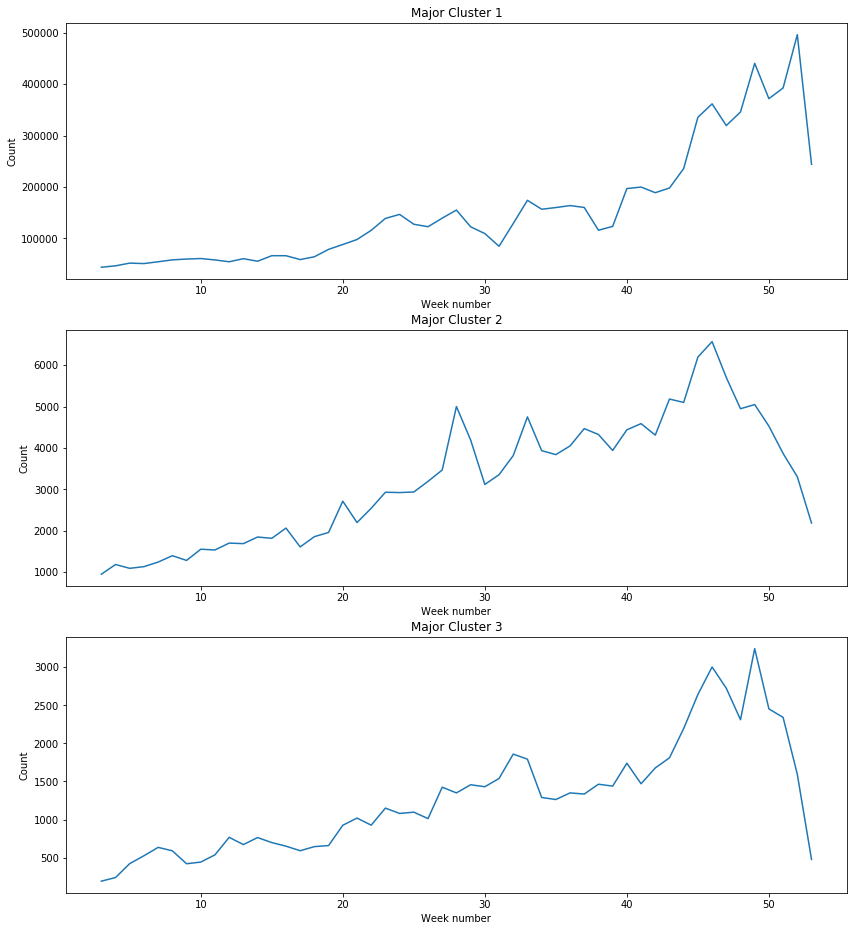

```python
# Lineplot of demand over time (weekly)
plt.figure(figsize=(14,16))
plt.subplot(311)
plt.title('Major Cluster 1')
plt.plot(df_grid[df_grid['major_cluster']==1].groupby('week_num').agg(count=('count','sum')))
plt.xlabel('Week number')
plt.ylabel('Count')

plt.subplot(312)
plt.title('Major Cluster 2')
plt.plot(df_grid[df_grid['major_cluster']==2].groupby('week_num').agg(count=('count','sum')))
plt.xlabel('Week number')
plt.ylabel('Count')

plt.subplot(313)
plt.title('Major Cluster 3')
plt.plot(df_grid[df_grid['major_cluster']==3].groupby('week_num').agg(count=('count','sum')))
plt.xlabel('Week number')
plt.ylabel('Count')
```

The dip in the last week is because of a lack of data (represented by days 364-366). It is apparent that there is a linear trend in the data. The future seems to have more ride requests than the past. What's also apparent is that, a lag of 1 week, that is using past week's demand to predict this week's demand, will be an underestimate of the actual demand. However, when combined with other features, it could be very powerful.

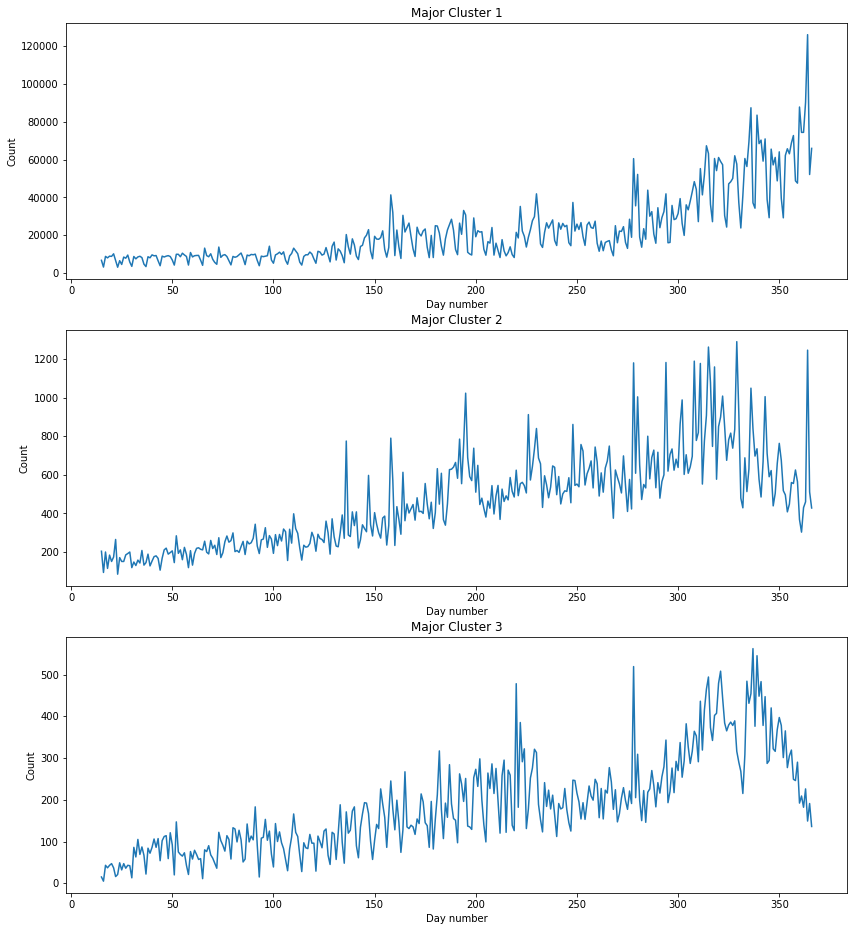

```python
# Lineplot of demand over time (daily)
plt.figure(figsize=(14,16))
plt.subplot(311)
plt.title('Major Cluster 1')
plt.plot(df_grid[df_grid['major_cluster']==1].groupby('day_num').agg(count=('count','sum')))
plt.xlabel('Day number')
plt.ylabel('Count')

plt.subplot(312)
plt.title('Major Cluster 2')
plt.plot(df_grid[df_grid['major_cluster']==2].groupby('day_num').agg(count=('count','sum')))
plt.xlabel('Day number')
plt.ylabel('Count')

plt.subplot(313)
plt.title('Major Cluster 3')
plt.plot(df_grid[df_grid['major_cluster']==3].groupby('day_num').agg(count=('count','sum')))
plt.xlabel('Day number')
plt.ylabel('Count')
```

This is very interesting. The overall trend, although linear, is very noisy. What's interesting is that the same patterns tend to repeat over a period of time. If we look at the data closely, the number of ride requests never seem to rise succesively. There is always a dip after about 2-3 days of rise

```python
# Calculating mean encodings (groupby of count on multiple features)
df_grid['minclust_enc'] = df_grid.groupby(['day_num','minor_cluster','hour'])['count'].transform('mean') # Not required
df_grid['majclust_enc'] = df_grid.groupby(['day_num','major_cluster','hour'])['count'].transform('mean')

# Lagging the encodings and deleting them since we will not know the encodings for the future observations
def lag_feature(df, lags, col):
    tmp = df[['day_num','minor_cluster','hour',col]]
    for i in lags:
        shifted = tmp.copy()
        shifted.columns = ['day_num','minor_cluster','hour', col+'_lag_'+str(i)]
        shifted['day_num'] += i
        df = pd.merge(df, shifted, on=['day_num','minor_cluster','hour'], how='left')
    df.drop(col, axis=1, inplace=True)
    return(df)

for col in ['minclust_enc', 'majclust_enc']:
    df_grid = lag_feature(df_grid, [7,14], col)
df_grid = df_grid[df_grid['day_num']>=15]
df_grid['diff_lag'] = df_grid['majclust_enc_lag_7'] - df_grid['majclust_enc_lag_14']
df_grid.fillna(0, inplace=True)
```

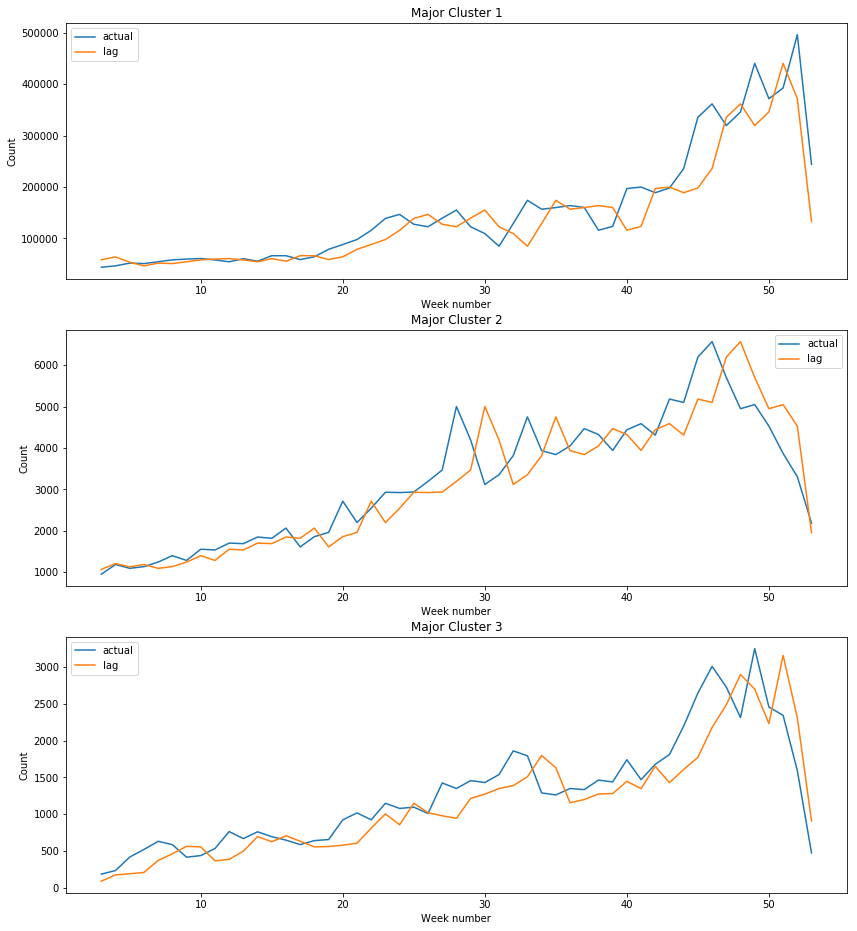

```python
# Lineplot of demand over time with a lag of 1 week
plt.figure(figsize=(14,16))
plt.subplot(311)
plt.title('Major Cluster 1')
plt.plot(df_grid[df_grid['major_cluster']==1].groupby('week_num').agg(count=('count','sum')), label='actual')
plt.plot(df_grid[df_grid['major_cluster']==1].groupby('week_num').agg(majclust_enc_lag_7=('majclust_enc_lag_14','sum')), label='lag')
plt.xlabel('Week number')
plt.ylabel('Count')
plt.legend()

plt.subplot(312)
plt.title('Major Cluster 2')
plt.plot(df_grid[df_grid['major_cluster']==2].groupby('week_num').agg(count=('count','sum')), label='actual')
plt.plot(df_grid[df_grid['major_cluster']==2].groupby('week_num').agg(majclust_enc_lag_7=('majclust_enc_lag_14','sum')), label='lag')
plt.xlabel('Week number')
plt.ylabel('Count')
plt.legend()

plt.subplot(313)
plt.title('Major Cluster 3')
plt.plot(df_grid[df_grid['major_cluster']==3].groupby('week_num').agg(count=('count','sum')), label='actual')
plt.plot(df_grid[df_grid['major_cluster']==3].groupby('week_num').agg(majclust_enc_lag_7=('majclust_enc_lag_14','sum')), label='lag')
plt.xlabel('Week number')
plt.ylabel('Count')
plt.legend()
```

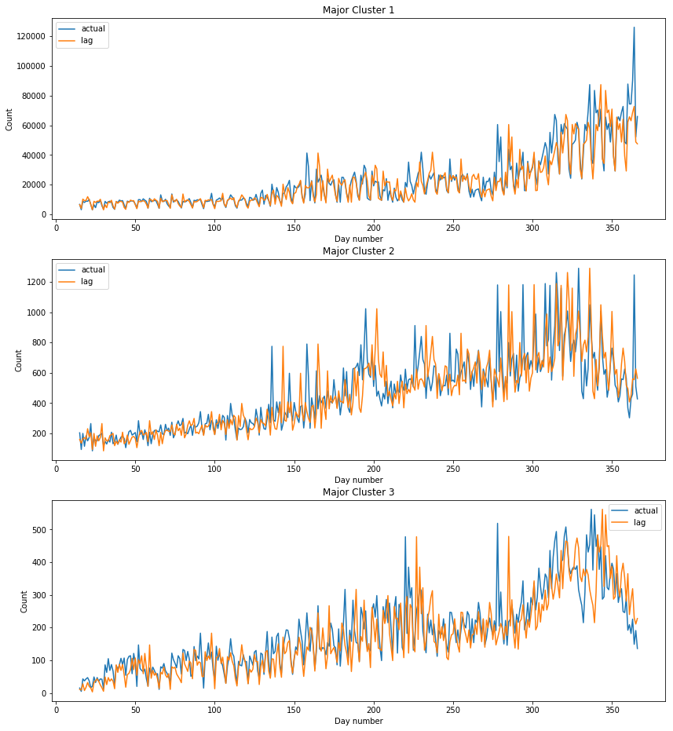

```python
# Lineplot of demand over time (daily)
plt.figure(figsize=(14,16))
plt.subplot(311)
plt.title('Major Cluster 1')
plt.plot(df_grid[df_grid['major_cluster']==1].groupby('day_num').agg(count=('count','sum')), label='actual')
plt.plot(df_grid[df_grid['major_cluster']==1].groupby('day_num').agg(majclust_enc_lag_7=('majclust_enc_lag_7','sum')), label='lag')
plt.xlabel('Day number')
plt.ylabel('Count')
plt.legend()

plt.subplot(312)
plt.title('Major Cluster 2')
plt.plot(df_grid[df_grid['major_cluster']==2].groupby('day_num').agg(count=('count','sum')), label='actual')
plt.plot(df_grid[df_grid['major_cluster']==2].groupby('day_num').agg(majclust_enc_lag_7=('majclust_enc_lag_7','sum')), label='lag')
plt.xlabel('Day number')
plt.ylabel('Count')
plt.legend()

plt.subplot(313)
plt.title('Major Cluster 3')
plt.plot(df_grid[df_grid['major_cluster']==3].groupby('day_num').agg(count=('count','sum')), label='actual')
plt.plot(df_grid[df_grid['major_cluster']==3].groupby('day_num').agg(majclust_enc_lag_7=('majclust_enc_lag_7','sum')), label='lag')
plt.xlabel('Day number')
plt.ylabel('Count')
plt.legend()
```

```python
#Correlation of count with the various lags
df_grid[['count']+[col for col in df_grid.columns if 'lag' in col]].corr()[['count']]
```

|  | count |
| --- | --- |
| count | 1.000000 |
| minclust_enc_lag_7 | 0.863162 |
| minclust_enc_lag_14 | 0.825017 |
| majclust_enc_lag_7 | 0.790212 |
| majclust_enc_lag_14 | 0.759029 |
| diff_lag | 0.138506 |

We can see that a lag of 7 days nicely aligns with the count of ride requests. This also shows in the correlation plot

#### How does the distribution of ride requests look on a major cluster vs hour level?

This is a question of interest because on an aggregate level, the hour of the day seems to be important. One thing to remember though is that the majority of Rapido's requests come from Bangalore, a job hub. Do other cities also have the same dependency on time?

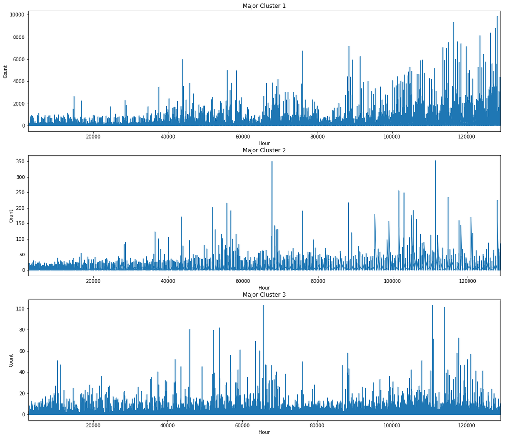

```python
plt.figure(figsize=(18,16))
plt.subplot(311)
plt.title('Major Cluster 1')
df_grid[df_grid['major_cluster']==1]['count'].plot()
plt.xlabel('Hour')
plt.ylabel('Count')

plt.subplot(312)
plt.title('Major Cluster 2')
df_grid[df_grid['major_cluster']==2]['count'].plot()
plt.xlabel('Hour')
plt.ylabel('Count')

plt.subplot(313)
plt.title('Major Cluster 3')
df_grid[df_grid['major_cluster']==3]['count'].plot()
plt.xlabel('Hour')
plt.ylabel('Count')
```

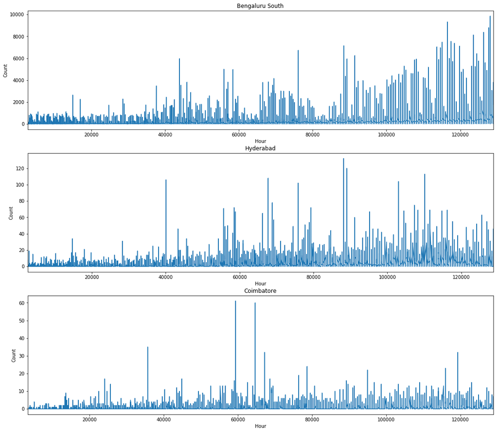

```python
plt.figure(figsize=(18,16))
plt.subplot(311)
plt.title('Bengaluru South')
df_grid[df_grid['minor_cluster']==16]['count'].plot()
plt.xlabel('Hour')
plt.ylabel('Count')

plt.subplot(312)
plt.title('Hyderabad')
df_grid[df_grid['minor_cluster']==2]['count'].plot()
plt.xlabel('Hour')
plt.ylabel('Count')

plt.subplot(313)
plt.title('Coimbatore')
df_grid[df_grid['minor_cluster']==11]['count'].plot()
plt.xlabel('Hour')
plt.ylabel('Count')
```

The count at an hour level is really noisy. If we look at the plot for Bengaluru South, there are periodic jumps which shows that the hour of the day really matters, however other towns do not show the same dependence. The forecast at an hour level could be really noisy. Even for Bengaluru, the standard deviation at an hour level is too high. The ride requests during peak hours is far greater than the average hourly requests for the same day.

```python
# mean and standard deviation of the count of ride requests for Bengaluru South
df_grid[df_grid['minor_cluster']==16].groupby('hour').agg(mean_count=('count', np.mean),stddev_count=('count', np.std))
```

| hour | mean_count | stddev_count |
| --- | --- | --- |
| 0 | 99.846591 | 113.841667 |
| 1 | 42.329545 | 69.972680 |
| 2 | 13.727273 | 24.879528 |
| 3 | 6.423295 | 11.421718 |
| 4 | 6.289773 | 10.510400 |
| 5 | 12.218750 | 18.273029 |
| 6 | 55.664773 | 61.761061 |
| 7 | 240.090909 | 210.505463 |
| 8 | 743.051136 | 830.118883 |
| 9 | 1520.965909 | 1810.209718 |
| 10 | 1400.917614 | 1510.484370 |
| 11 | 627.431818 | 597.400481 |
| 12 | 479.928977 | 456.393353 |
| 13 | 456.988636 | 419.981589 |
| 14 | 376.980114 | 342.908279 |
| 15 | 314.477273 | 244.280290 |
| 16 | 351.954545 | 247.555003 |
| 17 | 463.221591 | 322.095360 |
| 18 | 856.875000 | 767.670110 |
| 19 | 1096.710227 | 1065.046136 |
| 20 | 778.238636 | 808.315384 |
| 21 | 498.752841 | 446.523812 |
| 22 | 357.829545 | 337.847071 |
| 23 | 194.596591 | 178.751166 |

#### What is the Average Day Gap Between Requests (ADGBR) on a customer level?

```python
# Loading
df_customers = pd.read_csv('ct_rr.csv', usecols=['ts','number'], parse_dates=['ts'])
df_customers.drop_duplicates(inplace=True)
df_customers['number'] = df_customers['number'].astype(str)
df_customers = df_customers[~df_customers['number'].str.contains('None')]
df_customers['number'] = df_customers['number'].astype(np.int32)
df_customers.head(10)
```

|  | ts | number |
| --- | --- | --- |
| 0 | 2018-04-07 07:07:17 | 14626 |
| 1 | 2018-04-07 07:32:27 | 85490 |
| 2 | 2018-04-07 07:36:44 | 5408 |
| 3 | 2018-04-07 07:38:00 | 58940 |
| 4 | 2018-04-07 07:39:29 | 5408 |
| 5 | 2018-04-07 07:43:08 | 5408 |
| 6 | 2018-04-07 07:43:55 | 50266 |
| 7 | 2018-04-07 07:52:31 | 58940 |
| 8 | 2018-04-07 07:52:42 | 58940 |
| 9 | 2018-04-07 07:53:23 | 28126 |

Multiple requests are placed by the same customers in the same hour. This is probably a result of lack of demand fulfillment.

```python
# A check to see if there are any funny customer IDs
np.sort(df_customers['number'].unique())
```

```
array([   -1,     0,     1, ..., 99997, 99998, 99999])
```

-1 needs to be removed as it looks like it is a wrong customer ID

```python
df_customers = df_customers[df_customers['number']>-1]
print("Number of unique customer IDs is", df_customers['number'].nunique())

# To calculate day gap between requests
df_customers['previous_request'] = df_customers.groupby(['number'])['ts'].shift()
df_customers['dgbr'] = (df_customers['ts'] - df_customers['previous_request']).dt.days
```

```
Number of unique customer IDs is 94273
```

|  | adgbr |
| --- | --- |
| count | 88555.000000 |
| mean | 25.643552 |
| std | 36.164811 |
| min | 1.000000 |
| 25% | 7.083333 |
| 50% | 13.916667 |
| 75% | 28.500000 |
| max | 364.000000 |

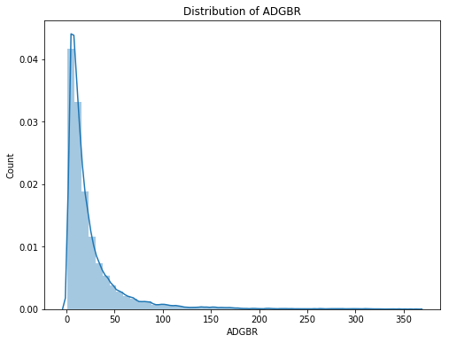

```python
# In order to get rid of same day requests, we need to consider dgbr with a floor of 1
display(df_customers[df_customers['dgbr']>0].groupby('number').agg(adgbr=('dgbr',np.mean)).describe())
plt.figure(figsize=(8,6))
plt.title('Distribution of ADGBR')
sns.distplot(df_customers[df_customers['dgbr']>0].groupby('number').agg(adgbr=('dgbr',np.mean)))
plt.xlabel('ADGBR')
plt.ylabel('Count')
```

The number of customers who have used Rapido atleast twice is almost 94%, which is great. However, the plot and the numerical summary shows that people do not usually use Rapido on a daily basis Thus, there is a high chance that a customer who used Rapido on Wednesday at 10 AM, may not use it again on Thursday or exactly a week from then. Hence we won't be using customer attributes in our model

## Modelling

The data at an hour level is too noisy to forecast. If the output of the demand prediction model were to be used as an input to a resource allocation/optimization model, we would want to account for the number of ride requests that could get placed a week from now. This would give sufficient time to hire riders and work on the technical infrastructure to handle requests, if necessary. We have seen from the plots above that the count of ride requests at a day level seem to "repeat" on a periodic basis (every 7 days). In order to work with as much data as possible, we will forecast at a minor_cluster and hour level and aggregate them to calculate the number of ride requests that could get placed on a given day.

The spikes in ride requests are not outliers. They need to be accounted for. However, for major cluster 3, there are a lot of zeros as the demand at certain hours for a lot of clusters is zero. If we were to use a single model for predicting demand for all clusters, the spikes and zeros could wreak havoc and result in poor forecasts. We will thus use 3 seperate models to predict for the 3 major clusters.

In order to account for the spikes, we will use MSE (Mean Squared Error) as the loss to minimize. MAE (Mean Absolute Error) usually favors smaller values. To calculate the difference ride requests and predictions, aggregated at a day level, MAPE (Mean Absolute Percentage Error) will be used

```python
xgboost_cols = list(set(df_grid.columns) - set(['day_num','count','major_cluster']))
linreg_cols = list(set(df_grid.columns) - set(['day_num','count','major_cluster','minor_cluster','dayofweek']))
```

```python
def mean_absolute_percentage_error(y_true, y_pred):
    return np.mean(np.abs((y_true - y_pred) / y_true)) * 100

def plot_coef(coef, predictors):
    plt.figure(figsize=(6,4))
    coef = pd.Series(coef, predictors).sort_values()
    coef.plot(kind='bar', title='Model Coefficients')

def plot_features(booster, figsize):
    fig, ax = plt.subplots(1,1,figsize=figsize)
    return plot_importance(booster=booster, ax=ax)

def calculate_mape_day(pred, valid, display_minclust_mape=False):
    df_valid = valid.copy()
    df_valid['pred'] = pred

    df_valid_grouped = df_valid.groupby(['minor_cluster','day_num']).agg(sum_count=('count',np.sum), sum_pred=('pred',np.sum))
    df_valid_grouped['mape_day'] = df_valid_grouped.apply(lambda group: mean_absolute_percentage_error(group['sum_count'], group['sum_pred']), axis=1)
    mape_day = df_valid_grouped['mape_day'].mean()
    print('The MAPE on a day level for the major cluster is', mape_day)
    if display_minclust_mape:
        display(df_valid_grouped)
    return(mape_day)
```

I have used a combination of Linear Regression and XGBoost to predict ride requests. The linear trend in the data calls for the use of a linear model and I have used a tree based model so as to work with categorical variables without one-hot encoding them and to reduce the variance of forecasts. This was somewhat inspired by the results I could achieve here - https://www.kaggle.com/akshayt19nayak/classification-vs-regression-gbdt-and-ensembling/notebook

In order to validate the forecasts, I have used nested time-series validation. This has been described here (https://towardsdatascience.com/time-series-nested-cross-validation-76adba623eb9). We consider all data until the 48th week to predict for the 49th week, then use all data until the 49th week to predict for the 50th week and so on. K-Fold cross validation cannot be used due to the temporal nature of the data

```python
def validate(linreg, xgboost, linreg_cols, xgboost_cols, df_train, cluster,
                         days_between=[(338,344),(345,352),(353,359),(360,366)]):

    # Subset major cluster
    df_train_cluster = df_train[(df_train['major_cluster']==cluster)]

    # Train and predict
    list_mape_day = []
    for days in days_between:
        start_date = days[0]
        end_date = days[1]
        train = df_train_cluster[(df_train_cluster['day_num']<start_date)]
        valid = df_train_cluster[(df_train_cluster['day_num']>=start_date)&(df_train_cluster['day_num']<=end_date)]

        # linear regression
        linreg.fit(train[linreg_cols], train['count'])
        linreg_pred = linreg.predict(valid[linreg_cols])

        # xgboost
        xgboost.fit(train[xgboost_cols], train['count'], eval_metric="rmse", early_stopping_rounds=10, verbose=0,
                    eval_set=[(train[xgboost_cols], train['count']),(valid[xgboost_cols], valid['count'])])
        xgboost_pred = xgboost.predict(valid[xgboost_cols])

        # Combining prediction
        pred = (linreg_pred + xgboost_pred)/2
        list_mape_day.append(calculate_mape_day(pred, valid))

    print('The average MAPE on all folds is', np.mean(list_mape_day))
    return(linreg, xgboost)
```

### Major Cluster 1

```python
linreg = LinearRegression()
# These parameters have been obtained after sufficient hyperparameter tuning
xgboost = XGBRegressor(
    max_depth=5,
    n_estimators=500,
    min_child_weight=30,
    colsample_bytree=0.75,
    subsample=0.75,
    eta=0.1,
    seed=42)
```

```python
linreg, xgboost = validate(linreg, xgboost, linreg_cols, xgboost_cols, df_grid, 1)
```

```
The MAPE on a day level for the major cluster is 18.777831380401015
The MAPE on a day level for the major cluster is 9.755006376248604
The MAPE on a day level for the major cluster is 13.862511172808988
The MAPE on a day level for the major cluster is 20.1658673031899
The average MAPE on all folds is 15.640304058162126
```

The feature importance of XGBoost plotted below shows how useful each feature was in the construction of the boosted decision trees within the model. The more an attribute is used to split data, the higher its relative importance. The lagged variables seem to be important in predicting future requests.

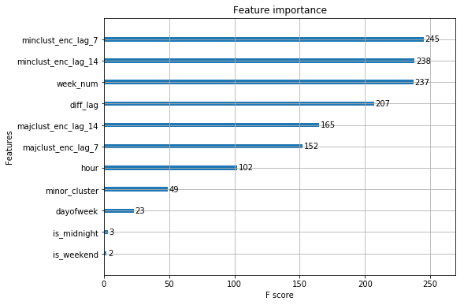

```python
plot_features(xgboost, (8,6))
```

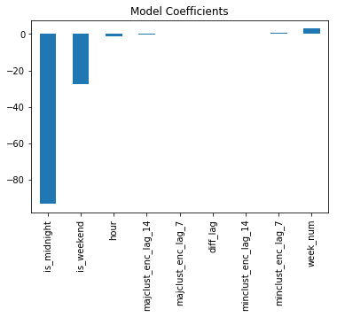

```python
# Plots the coefficients of the linear regression model
plot_coef(linreg.coef_, linreg_cols)
```

The coefficients of the linear model are almost zero for the same variables that XGBoost finds useful. The binary features is_midnight and is_weekend, seem to have the strongest influence on predictions

### Major Cluster 2

```python
linreg = LinearRegression()
regressor = XGBRegressor(
    max_depth=6,
    n_estimators=500,
    min_child_weight=70,
    colsample_bytree=0.75,
    subsample=0.75,
    eta=0.1,
    seed=42)
```

```python
linreg, xgboost = validate(linreg, xgboost, linreg_cols, xgboost_cols, df_grid, 2)
```

```
The MAPE on a day level for the major cluster is 20.830417547836735
The MAPE on a day level for the major cluster is 23.634417183306716
The MAPE on a day level for the major cluster is 29.669123236561294
The MAPE on a day level for the major cluster is 60.26050148784499
The average MAPE on all folds is 33.598614863887434
```

The MAPE is higher for this cluster because of the base. The count of ride requests in these towns is much lesser than Bangalore. A MAPE of 33% in this context means that if the number of ride requests on a given day was 10, we predicted a demand of 7. There is drastic up-down movement in the last 4 weeks of the timeseries for major cluster 2

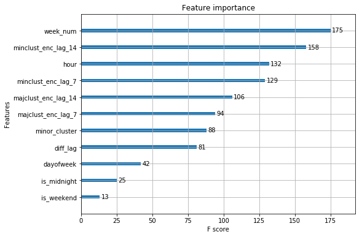

```python
plot_features(xgboost, (8,6))
```

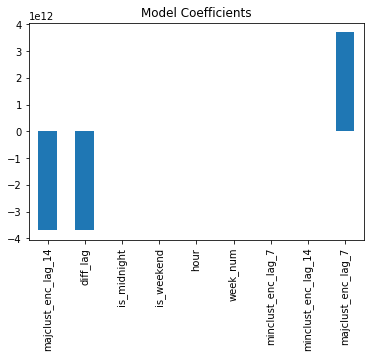

```python
plot_coef(linreg.coef_, linreg_cols)
```

### Major Cluster 3

```python
linreg = LinearRegression()
regressor = XGBRegressor(
    max_depth=3,
    n_estimators=500,
    min_child_weight=100,
    colsample_bytree=0.75,
    subsample=0.75,
    eta=0.1,
    seed=42)
```

```python
linreg, xgboost = validate(linreg, xgboost, linreg_cols, xgboost_cols, df_grid, 3)
```

```
The MAPE on a day level for the major cluster is 149.1231604401044
The MAPE on a day level for the major cluster is 214.070059813663
The MAPE on a day level for the major cluster is 181.97960143789243
The MAPE on a day level for the major cluster is 229.7802277909085
The average MAPE on all folds is 193.7382623706421
```

This is one area where the MAPE is disastrous. A difference of 1, means that the MAPE is already at a 100%. This needs to be improved.

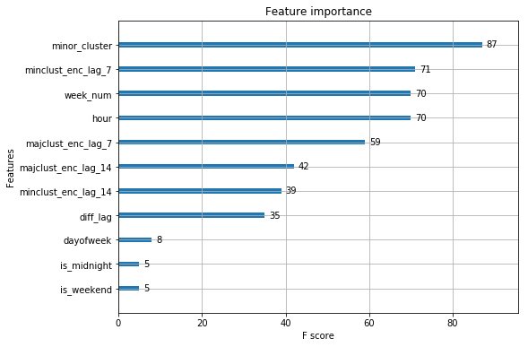

```python
plot_features(xgboost, (8,6))
```

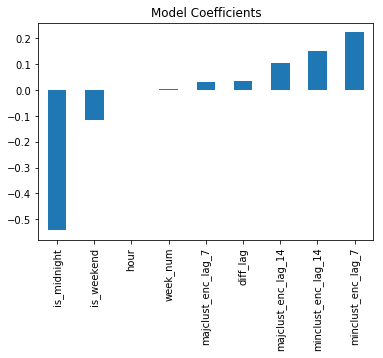

```python
plot_coef(linreg.coef_, linreg_cols)
```